# Shiny App - plotting and fitting ‘swiss’ data

Ivy Woo

24 January, 2021

# App functions

This is a simple app which generates a scatter plot on data from the ‘swiss’ dataset in R.

In the app UI, select a variable as the independent variable and another one as the dependent variable, a scatter plot of the two variables will be displayed.

A linear regression can be fitted by checking the relevant box. The regression line will be added to the plot, the regression coefficients together with the R-squared value will be provided.

# ‘swiss’ dataset

The app uses data from the ‘swiss’ dataset which has 6 variables. All 6 variables are available as the choice of independent/dependent variable in the app.

Below is how the ‘swiss’ dataset looks like:

```r
head(swiss)
```

```
             Fertility Agriculture Examination Education Catholic
Courtelary        80.2        17.0          15        12     9.96
Delemont          83.1        45.1           6         9    84.84
Franches-Mnt      92.5        39.7           5         5    93.40
Moutier           85.8        36.5          12         7    33.77
Neuveville        76.9        43.5          17        15     5.16
Porrentruy        76.1        35.3           9         7    90.57
             Infant.Mortality
Courtelary               22.2
Delemont                 22.2
Franches-Mnt             20.2
Moutier                  20.3
Neuveville               20.6
Porrentruy               26.6
```

# Scatter plot

Here is an example of the scatter plot that will be generated, where ‘Agriculture’ is chosen as the independent variable and ‘Fertility’ as the dependent variable.

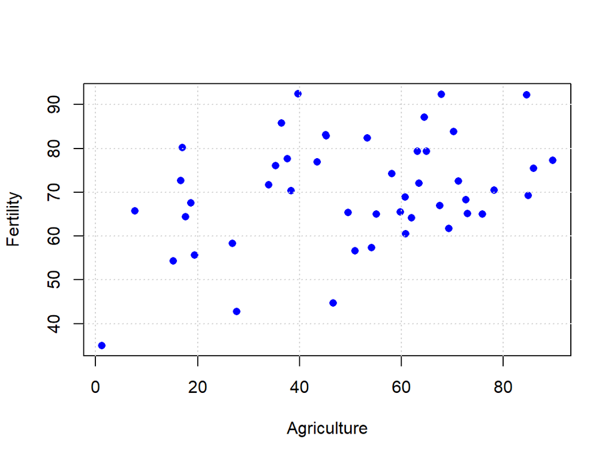

Upon checking the linear regression box, the regression line (in red) will be shown in the plot, the regression coefficients and the R-squared value will be given below the plot.

Thank you! Have fun in playing around with the app :)